# Ford Go Bike Data 2018 Analysis and Visualisation

## Preliminary Wrangling

```python
# import all packages and set plots to be embedded inline
import numpy as np
import pandas as pd
import matplotlib.pyplot as plt
import seaborn as sb

%matplotlib inline
import glob
import os
```

# Creating one master data frame and master data file from all the csv files downloaded (2018-2019)

path=r'C:\Users\rkumar35\Udacity Course\Udacity Project 5\communicate-data-project-template (1)\Project Template'

all_files=glob.glob(os.path.join(path, "*.csv"))

all_files

list_csv=[]

for file in all_files:

```
list_csv.append(pd.read_csv(file,sep=','))
```

df_master=pd.concat(list_csv)

df_master.to_csv('master_data_file.csv',index=False)

### ASSESS

```python
df_master=pd.read_csv('master_data_file.csv',sep=',')
```

```python
df_master.head()
```

|  | duration_sec | start_time | end_time | start_station_id | start_station_name | start_station_latitude | start_station_longitude | end_station_id | end_station_name | end_station_latitude | end_station_longitude | bike_id | user_type | member_birth_year | member_gender | bike_share_for_all_trip |
| --- | --- | --- | --- | --- | --- | --- | --- | --- | --- | --- | --- | --- | --- | --- | --- | --- |
| 0 | 75284 | 2018-01-31 22:52:35.2390 | 2018-02-01 19:47:19.8240 | 120.0 | Mission Dolores Park | 37.761420 | -122.426435 | 285.0 | Webster St at O'Farrell St | 37.783521 | -122.431158 | 2765 | Subscriber | 1986.0 | Male | No |
| 1 | 85422 | 2018-01-31 16:13:34.3510 | 2018-02-01 15:57:17.3100 | 15.0 | San Francisco Ferry Building (Harry Bridges Pl... | 37.795392 | -122.394203 | 15.0 | San Francisco Ferry Building (Harry Bridges Pl... | 37.795392 | -122.394203 | 2815 | Customer | NaN | NaN | No |
| 2 | 71576 | 2018-01-31 14:23:55.8890 | 2018-02-01 10:16:52.1160 | 304.0 | Jackson St at 5th St | 37.348759 | -121.894798 | 296.0 | 5th St at Virginia St | 37.325998 | -121.877120 | 3039 | Customer | 1996.0 | Male | No |
| 3 | 61076 | 2018-01-31 14:53:23.5620 | 2018-02-01 07:51:20.5000 | 75.0 | Market St at Franklin St | 37.773793 | -122.421239 | 47.0 | 4th St at Harrison St | 37.780955 | -122.399749 | 321 | Customer | NaN | NaN | No |
| 4 | 39966 | 2018-01-31 19:52:24.6670 | 2018-02-01 06:58:31.0530 | 74.0 | Laguna St at Hayes St | 37.776435 | -122.426244 | 19.0 | Post St at Kearny St | 37.788975 | -122.403452 | 617 | Subscriber | 1991.0 | Male | No |

```python
df_master.sample(20)
```

|  | duration_sec | start_time | end_time | start_station_id | start_station_name | start_station_latitude | start_station_longitude | end_station_id | end_station_name | end_station_latitude | end_station_longitude | bike_id | user_type | member_birth_year | member_gender | bike_share_for_all_trip |
| --- | --- | --- | --- | --- | --- | --- | --- | --- | --- | --- | --- | --- | --- | --- | --- | --- |
| 4537484 | 6118 | 2019-04-07 13:51:57.8760 | 2019-04-07 15:33:56.7720 | 377.0 | Fell St at Stanyan St | 37.771917 | -122.453704 | 71.0 | Broderick St at Oak St | 37.773063 | -122.439078 | 5426 | Customer | 1979.0 | Other | No |
| 396516 | 928 | 2018-04-12 17:07:31.5370 | 2018-04-12 17:23:00.4630 | 323.0 | Broadway at Kearny | 37.798014 | -122.405950 | 64.0 | 5th St at Brannan St | 37.776754 | -122.399018 | 2899 | Subscriber | 1979.0 | Male | No |
| 638393 | 900 | 2018-06-28 16:17:36.8850 | 2018-06-28 16:32:37.2840 | 104.0 | 4th St at 16th St | 37.767045 | -122.390833 | 15.0 | San Francisco Ferry Building (Harry Bridges Pl... | 37.795392 | -122.394203 | 1885 | Customer | 1969.0 | Male | No |
| 193867 | 502 | 2018-02-02 16:35:20.6880 | 2018-02-02 16:43:42.8160 | 81.0 | Berry St at 4th St | 37.775880 | -122.393170 | 16.0 | Steuart St at Market St | 37.794130 | -122.394430 | 2599 | Subscriber | 1982.0 | Male | No |
| 2957880 | 686 | 2018-08-20 07:56:12.5430 | 2018-08-20 08:07:39.4520 | 286.0 | San Carlos St at 11th St | 37.336466 | -121.876613 | 282.0 | Market St at Park St | 37.332426 | -121.890349 | 1845 | Subscriber | 1955.0 | Female | No |
| 4014344 | 316 | 2019-02-15 15:48:13.0810 | 2019-02-15 15:53:29.3360 | 50.0 | 2nd St at Townsend St | 37.780526 | -122.390288 | 16.0 | Steuart St at Market St | 37.794130 | -122.394430 | 6488 | Subscriber | 1975.0 | Male | No |
| 1082476 | 643 | 2018-08-21 18:15:26.4160 | 2018-08-21 18:26:10.2250 | 19.0 | Post St at Kearny St | 37.788975 | -122.403452 | 66.0 | 3rd St at Townsend St | 37.778742 | -122.392741 | 4387 | Subscriber | 1982.0 | Male | No |
| 1512133 | 895 | 2018-10-13 18:43:13.4910 | 2018-10-13 18:58:08.8180 | 6.0 | The Embarcadero at Sansome St | 37.804770 | -122.403234 | 58.0 | Market St at 10th St | 37.776619 | -122.417385 | 4053 | Subscriber | 1995.0 | Male | No |
| 839659 | 708 | 2018-07-28 14:18:50.5040 | 2018-07-28 14:30:38.8730 | 6.0 | The Embarcadero at Sansome St | 37.804770 | -122.403234 | 3.0 | Powell St BART Station (Market St at 4th St) | 37.786375 | -122.404904 | 1168 | Subscriber | 1986.0 | Male | No |
| 629286 | 453 | 2018-06-29 17:58:29.7880 | 2018-06-29 18:06:03.4060 | 21.0 | Montgomery St BART Station (Market St at 2nd St) | 37.789625 | -122.400811 | 323.0 | Broadway at Kearny | 37.798014 | -122.405950 | 3698 | Subscriber | 1990.0 | Male | No |
| 3117816 | 580 | 2018-09-24 12:18:02.5830 | 2018-09-24 12:27:43.0620 | 14.0 | Clay St at Battery St | 37.795001 | -122.399970 | 5.0 | Powell St BART Station (Market St at 5th St) | 37.783899 | -122.408445 | 3531 | Subscriber | 1989.0 | Female | No |
| 1380740 | 236 | 2018-09-04 18:39:53.9080 | 2018-09-04 18:43:50.3570 | 96.0 | Dolores St at 15th St | 37.766210 | -122.426614 | 121.0 | Mission Playground | 37.759210 | -122.421339 | 3978 | Subscriber | 1993.0 | Male | No |
| 1753083 | 402 | 2018-12-24 10:56:43.0820 | 2018-12-24 11:03:25.5590 | 24.0 | Spear St at Folsom St | 37.789677 | -122.390428 | 20.0 | Mechanics Monument Plaza (Market St at Bush St) | 37.791300 | -122.399051 | 2366 | Customer | 1992.0 | Male | No |
| 40276 | 719 | 2018-01-20 14:56:45.7920 | 2018-01-20 15:08:45.6570 | 96.0 | Dolores St at 15th St | 37.766210 | -122.426614 | 41.0 | Golden Gate Ave at Polk St | 37.781270 | -122.418740 | 544 | Subscriber | 1989.0 | Male | No |
| 4189515 | 1029 | 2019-03-21 12:28:57.7200 | 2019-03-21 12:46:07.6760 | 134.0 | Valencia St at 24th St | 37.752428 | -122.420628 | 130.0 | 22nd St Caltrain Station | 37.757288 | -122.392051 | 5286 | Customer | 1983.0 | Male | No |
| 3747892 | 215 | 2019-01-29 18:43:54.3990 | 2019-01-29 18:47:29.4060 | 126.0 | Esprit Park | 37.761634 | -122.390648 | 93.0 | 4th St at Mission Bay Blvd S | 37.770407 | -122.391198 | 4826 | Subscriber | 1966.0 | Male | No |
| 2522900 | 1067 | 2018-06-25 21:55:00.7610 | 2018-06-25 22:12:48.2240 | 19.0 | Post St at Kearny St | 37.788975 | -122.403452 | 55.0 | Webster St at Grove St | 37.777053 | -122.429558 | 496 | Subscriber | 1991.0 | Female | No |
| 3252265 | 965 | 2018-09-03 14:07:02.6770 | 2018-09-03 14:23:08.1460 | 55.0 | Webster St at Grove St | 37.777053 | -122.429558 | 3.0 | Powell St BART Station (Market St at 4th St) | 37.786375 | -122.404904 | 3119 | Customer | 1972.0 | Male | No |
| 421994 | 337 | 2018-04-05 18:45:08.0960 | 2018-04-05 18:50:45.9240 | 310.0 | San Fernando St at 4th St | 37.335885 | -121.885660 | 286.0 | San Carlos St at 11th St | 37.336466 | -121.876613 | 1315 | Subscriber | 1957.0 | Female | No |
| 3644108 | 414 | 2018-12-18 10:28:44.7200 | 2018-12-18 10:35:39.4690 | 114.0 | Rhode Island St at 17th St | 37.764478 | -122.402570 | 58.0 | Market St at 10th St | 37.776619 | -122.417385 | 4823 | Subscriber | 1984.0 | Male | No |

```python
df_master.info(null_counts=True)
```

```
<class 'pandas.core.frame.DataFrame'>
RangeIndex: 4598346 entries, 0 to 4598345
Data columns (total 16 columns):
duration_sec               4598346 non-null int64
start_time                 4598346 non-null object
end_time                   4598346 non-null object
start_station_id           4574074 non-null float64
start_station_name         4574074 non-null object
start_station_latitude     4598346 non-null float64
start_station_longitude    4598346 non-null float64
end_station_id             4574074 non-null float64
end_station_name           4574074 non-null object
end_station_latitude       4598346 non-null float64
end_station_longitude      4598346 non-null float64
bike_id                    4598346 non-null int64
user_type                  4598346 non-null object
member_birth_year          4336003 non-null float64
member_gender              4336708 non-null object
bike_share_for_all_trip    4598346 non-null object
dtypes: float64(7), int64(2), object(7)
memory usage: 561.3+ MB
```

```python
df_master.describe()
```

|  | duration_sec | start_station_id | start_station_latitude | start_station_longitude | end_station_id | end_station_latitude | end_station_longitude | bike_id | member_birth_year |
| --- | --- | --- | --- | --- | --- | --- | --- | --- | --- |
| count | 4.598346e+06 | 4.574074e+06 | 4.598346e+06 | 4.598346e+06 | 4.574074e+06 | 4.598346e+06 | 4.598346e+06 | 4.598346e+06 | 4.336003e+06 |
| mean | 8.420302e+02 | 1.233562e+02 | 3.776766e+01 | -1.223502e+02 | 1.218513e+02 | 3.776764e+01 | -1.223493e+02 | 2.673262e+03 | 1.983403e+03 |
| std | 2.289678e+03 | 1.033410e+02 | 1.057797e-01 | 1.672556e-01 | 1.033634e+02 | 1.282155e-01 | 2.884299e-01 | 1.617541e+03 | 1.039097e+01 |
| min | 6.100000e+01 | 3.000000e+00 | 0.000000e+00 | -1.224737e+02 | 3.000000e+00 | 0.000000e+00 | -1.224737e+02 | 1.100000e+01 | 1.878000e+03 |
| 25% | 3.480000e+02 | 3.600000e+01 | 3.777041e+01 | -1.224117e+02 | 3.000000e+01 | 3.777106e+01 | -1.224107e+02 | 1.379000e+03 | 1.978000e+03 |
| 50% | 5.520000e+02 | 9.000000e+01 | 3.778107e+01 | -1.223974e+02 | 8.900000e+01 | 3.778107e+01 | -1.223971e+02 | 2.625000e+03 | 1.986000e+03 |
| 75% | 8.650000e+02 | 1.950000e+02 | 3.779647e+01 | -1.222880e+02 | 1.930000e+02 | 3.779728e+01 | -1.222894e+02 | 3.690000e+03 | 1.991000e+03 |
| max | 8.636600e+04 | 4.200000e+02 | 4.551000e+01 | 0.000000e+00 | 4.200000e+02 | 4.551000e+01 | 0.000000e+00 | 7.108000e+03 | 2.001000e+03 |

```python
df_master.shape
```

```
(4598346, 16)
```

```python
df_master.duplicated().sum()
```

```
787715
```

### Quality Issues

```
1) Data types of columns start_station_id,end_station_id,bike_id can be set to string for better analysis
2) Incorrect Data types of columns start_time,end_time
3) Data types of user type, gender and bike_share_for_all_trip can be set to category
5) Can calculate age from member_birth_year
6) Member_birth_year shows age >> 100
4) Data type of member_birth_year_is not in int
7) Missing Values in start_station_id,start_station_name,end_station_id,end_station_name,member_birth_year,member_gender
8) duration should be in minutes
9) Extracting infromation such as month,day,hour from start_time & end_time columns
```

## CLEANING

```python
df_master_clean=df_master.copy()
```

#### Define: Correcting datatypes with more appropriate data types for analysis and visualization

#### Code

```python
# data_types of bike id, start_station_id, end_station_id to str
df_master_clean.start_station_id = df_master_clean.start_station_id.astype(str)
df_master_clean.end_station_id = df_master_clean.end_station_id.astype(str)
df_master_clean.bike_id = df_master_clean.bike_id.astype(str)
```

```python
# dates to timestamps
df_master_clean.start_time = pd.to_datetime(df_master_clean.start_time)
df_master_clean.end_time = pd.to_datetime(df_master_clean.end_time)
```

```python
# datatypes of user type, gender and bike_share_for_all_trip to category
df_master_clean.user_type = df_master_clean.user_type.astype('category')
df_master_clean.member_gender = df_master_clean.member_gender.astype('category')
df_master_clean.bike_share_for_all_trip = df_master_clean.bike_share_for_all_trip.astype('category')
```

#### Test

```python
df_master_clean.info()
```

```
<class 'pandas.core.frame.DataFrame'>
RangeIndex: 4598346 entries, 0 to 4598345
Data columns (total 16 columns):
duration_sec               int64
start_time                 datetime64[ns]
end_time                   datetime64[ns]
start_station_id           object
start_station_name         object
start_station_latitude     float64
start_station_longitude    float64
end_station_id             object
end_station_name           object
end_station_latitude       float64
end_station_longitude      float64
bike_id                    object
user_type                  category
member_birth_year          float64
member_gender              category
bike_share_for_all_trip    category
dtypes: category(3), datetime64[ns](2), float64(5), int64(1), object(5)
memory usage: 469.2+ MB
```

#### Define: Calculating age by subtractiing member_birth_year from 2019

#### Code

```python
# substract the birth year from the current year
df_master_clean['member_age'] = 2019-df_master_clean['member_birth_year']
```

#### Test

```python
df_master_clean.head()
```

|  | duration_sec | start_time | end_time | start_station_id | start_station_name | start_station_latitude | start_station_longitude | end_station_id | end_station_name | end_station_latitude | end_station_longitude | bike_id | user_type | member_birth_year | member_gender | bike_share_for_all_trip | member_age |
| --- | --- | --- | --- | --- | --- | --- | --- | --- | --- | --- | --- | --- | --- | --- | --- | --- | --- |
| 0 | 75284 | 2018-01-31 22:52:35.239 | 2018-02-01 19:47:19.824 | 120.0 | Mission Dolores Park | 37.761420 | -122.426435 | 285.0 | Webster St at O'Farrell St | 37.783521 | -122.431158 | 2765 | Subscriber | 1986.0 | Male | No | 33.0 |
| 1 | 85422 | 2018-01-31 16:13:34.351 | 2018-02-01 15:57:17.310 | 15.0 | San Francisco Ferry Building (Harry Bridges Pl... | 37.795392 | -122.394203 | 15.0 | San Francisco Ferry Building (Harry Bridges Pl... | 37.795392 | -122.394203 | 2815 | Customer | NaN | NaN | No | NaN |
| 2 | 71576 | 2018-01-31 14:23:55.889 | 2018-02-01 10:16:52.116 | 304.0 | Jackson St at 5th St | 37.348759 | -121.894798 | 296.0 | 5th St at Virginia St | 37.325998 | -121.877120 | 3039 | Customer | 1996.0 | Male | No | 23.0 |
| 3 | 61076 | 2018-01-31 14:53:23.562 | 2018-02-01 07:51:20.500 | 75.0 | Market St at Franklin St | 37.773793 | -122.421239 | 47.0 | 4th St at Harrison St | 37.780955 | -122.399749 | 321 | Customer | NaN | NaN | No | NaN |
| 4 | 39966 | 2018-01-31 19:52:24.667 | 2018-02-01 06:58:31.053 | 74.0 | Laguna St at Hayes St | 37.776435 | -122.426244 | 19.0 | Post St at Kearny St | 37.788975 | -122.403452 | 617 | Subscriber | 1991.0 | Male | No | 28.0 |

#### Define : We can see there are outlier present in the age of members to fix by keeping only the proportion of ages in which maximum number of members fall and then will convert data type of member_age and member_birth_year to int.

### Code

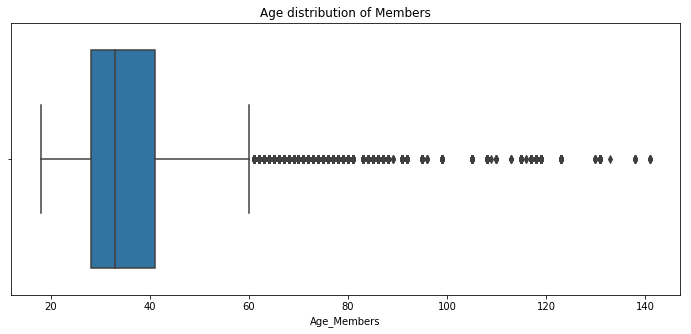

```python
plt.figure(figsize = [12, 5])

sb.boxplot(data=df_master_clean, x='member_age');
plt.title("Age distribution of Members")
plt.xlabel("Age_Members");
```

```python
df_master_clean.member_age.describe(percentiles = [.99])
```

```
count    4.336003e+06
mean     3.559745e+01
std      1.039097e+01
min      1.800000e+01
50%      3.300000e+01
99%      6.500000e+01
max      1.410000e+02
Name: member_age, dtype: float64
```

#### 99% users are under the age of 65 so we will only keep records where member_age <=65

```python
df_master_clean = df_master_clean.query('member_age <= 65')
# converting data type of member_age and member_birth_year to int
df_master_clean.member_age = df_master_clean.member_age.astype(int)
df_master_clean.member_birth_year = df_master_clean.member_birth_year.astype(int)
```

#### Test

```python
df_master_clean['member_age'].value_counts()
```

```
31    254046
30    213841
32    212752
29    206271
26    199342
28    196483
34    190850
33    188281
27    178043
35    173527
25    161126
36    159567
37    149647
24    137291
38    121080
```

[output cut: 34 more lines]

```python
df_master_clean.info()
```

```
<class 'pandas.core.frame.DataFrame'>
Int64Index: 4293230 entries, 0 to 4598345
Data columns (total 17 columns):
duration_sec               int64
start_time                 datetime64[ns]
end_time                   datetime64[ns]
start_station_id           object
start_station_name         object
start_station_latitude     float64
start_station_longitude    float64
end_station_id             object
end_station_name           object
end_station_latitude       float64
end_station_longitude      float64
bike_id                    object
user_type                  category
member_birth_year          int32
member_gender              category
bike_share_for_all_trip    category
member_age                 int32
dtypes: category(3), datetime64[ns](2), float64(4), int32(2), int64(1), object(5)
memory usage: 470.8+ MB
```

#### Define: Removing the missing values

#### Code

```python
df_master_clean.info(null_counts=True)
```

```
<class 'pandas.core.frame.DataFrame'>
Int64Index: 4293230 entries, 0 to 4598345
Data columns (total 17 columns):
duration_sec               4293230 non-null int64
start_time                 4293230 non-null datetime64[ns]
end_time                   4293230 non-null datetime64[ns]
start_station_id           4293230 non-null object
start_station_name         4269684 non-null object
start_station_latitude     4293230 non-null float64
start_station_longitude    4293230 non-null float64
end_station_id             4293230 non-null object
end_station_name           4269684 non-null object
end_station_latitude       4293230 non-null float64
end_station_longitude      4293230 non-null float64
bike_id                    4293230 non-null object
user_type                  4293230 non-null category
member_birth_year          4293230 non-null int32
member_gender              4293230 non-null category
bike_share_for_all_trip    4293230 non-null category
member_age                 4293230 non-null int32
dtypes: category(3), datetime64[ns](2), float64(4), int32(2), int64(1), object(5)
memory usage: 470.8+ MB
```

```python
df_master_clean.dropna(axis=0, inplace=True)
```

#### Test

```python
df_master_clean.info(null_counts=True)
```

```
<class 'pandas.core.frame.DataFrame'>
Int64Index: 4269684 entries, 0 to 4598345
Data columns (total 17 columns):
duration_sec               4269684 non-null int64
start_time                 4269684 non-null datetime64[ns]
end_time                   4269684 non-null datetime64[ns]
start_station_id           4269684 non-null object
start_station_name         4269684 non-null object
start_station_latitude     4269684 non-null float64
start_station_longitude    4269684 non-null float64
end_station_id             4269684 non-null object
end_station_name           4269684 non-null object
end_station_latitude       4269684 non-null float64
end_station_longitude      4269684 non-null float64
bike_id                    4269684 non-null object
user_type                  4269684 non-null category
member_birth_year          4269684 non-null int32
member_gender              4269684 non-null category
bike_share_for_all_trip    4269684 non-null category
member_age                 4269684 non-null int32
dtypes: category(3), datetime64[ns](2), float64(4), int32(2), int64(1), object(5)
memory usage: 468.3+ MB
```

#### Define:Duration in seconds to duration in minutes

#### Code

```python
df_master_clean['duration_min'] = df_master_clean['duration_sec']/60
df_master_clean['duration_min'] = df_master_clean['duration_min'].astype(int)
```

#### Test

```python
df_master_clean.head()
```

|  | duration_sec | start_time | end_time | start_station_id | start_station_name | start_station_latitude | start_station_longitude | end_station_id | end_station_name | end_station_latitude | end_station_longitude | bike_id | user_type | member_birth_year | member_gender | bike_share_for_all_trip | member_age | duration_min |
| --- | --- | --- | --- | --- | --- | --- | --- | --- | --- | --- | --- | --- | --- | --- | --- | --- | --- | --- |
| 0 | 75284 | 2018-01-31 22:52:35.239 | 2018-02-01 19:47:19.824 | 120.0 | Mission Dolores Park | 37.761420 | -122.426435 | 285.0 | Webster St at O'Farrell St | 37.783521 | -122.431158 | 2765 | Subscriber | 1986 | Male | No | 33 | 1254 |
| 2 | 71576 | 2018-01-31 14:23:55.889 | 2018-02-01 10:16:52.116 | 304.0 | Jackson St at 5th St | 37.348759 | -121.894798 | 296.0 | 5th St at Virginia St | 37.325998 | -121.877120 | 3039 | Customer | 1996 | Male | No | 23 | 1192 |
| 4 | 39966 | 2018-01-31 19:52:24.667 | 2018-02-01 06:58:31.053 | 74.0 | Laguna St at Hayes St | 37.776435 | -122.426244 | 19.0 | Post St at Kearny St | 37.788975 | -122.403452 | 617 | Subscriber | 1991 | Male | No | 28 | 666 |
| 6 | 453 | 2018-01-31 23:53:53.632 | 2018-02-01 00:01:26.805 | 110.0 | 17th & Folsom Street Park (17th St at Folsom St) | 37.763708 | -122.415204 | 134.0 | Valencia St at 24th St | 37.752428 | -122.420628 | 3571 | Subscriber | 1988 | Male | No | 31 | 7 |
| 7 | 180 | 2018-01-31 23:52:09.903 | 2018-01-31 23:55:10.807 | 81.0 | Berry St at 4th St | 37.775880 | -122.393170 | 93.0 | 4th St at Mission Bay Blvd S | 37.770407 | -122.391198 | 1403 | Subscriber | 1980 | Male | No | 39 | 3 |

#### Define: Extracting infromation such as month,day,hour from start_time & end_time columns

#### Code

```python
# Extracting Start time month (January - December) name
df_master_clean['start_time_month'] = df_master_clean['start_time'].dt.strftime('%B')
```

```python
# Extracting Start time month (1-12) number
df_master_clean['start_time_month_num'] = df_master_clean['start_time'].dt.month.astype(int)
```

```python
# Extracting Start time weekday
df_master_clean['start_time_weekday'] = df_master_clean['start_time'].dt.strftime('%a')
```

```python
# Extracting Start and end time hour
df_master_clean['start_time_hour'] = df_master_clean['start_time'].dt.hour
df_master_clean['end_time_hour'] = df_master_clean['end_time'].dt.hour
```

#### Test

```python
df_master_clean.head(5)
```

|  | duration_sec | start_time | end_time | start_station_id | start_station_name | start_station_latitude | start_station_longitude | end_station_id | end_station_name | end_station_latitude | ... | member_birth_year | member_gender | bike_share_for_all_trip | member_age | duration_min | start_time_month | start_time_month_num | start_time_weekday | start_time_hour | end_time_hour |
| --- | --- | --- | --- | --- | --- | --- | --- | --- | --- | --- | --- | --- | --- | --- | --- | --- | --- | --- | --- | --- | --- |
| 0 | 75284 | 2018-01-31 22:52:35.239 | 2018-02-01 19:47:19.824 | 120.0 | Mission Dolores Park | 37.761420 | -122.426435 | 285.0 | Webster St at O'Farrell St | 37.783521 | ... | 1986 | Male | No | 33 | 1254 | January | 1 | Wed | 22 | 19 |
| 2 | 71576 | 2018-01-31 14:23:55.889 | 2018-02-01 10:16:52.116 | 304.0 | Jackson St at 5th St | 37.348759 | -121.894798 | 296.0 | 5th St at Virginia St | 37.325998 | ... | 1996 | Male | No | 23 | 1192 | January | 1 | Wed | 14 | 10 |
| 4 | 39966 | 2018-01-31 19:52:24.667 | 2018-02-01 06:58:31.053 | 74.0 | Laguna St at Hayes St | 37.776435 | -122.426244 | 19.0 | Post St at Kearny St | 37.788975 | ... | 1991 | Male | No | 28 | 666 | January | 1 | Wed | 19 | 6 |
| 6 | 453 | 2018-01-31 23:53:53.632 | 2018-02-01 00:01:26.805 | 110.0 | 17th & Folsom Street Park (17th St at Folsom St) | 37.763708 | -122.415204 | 134.0 | Valencia St at 24th St | 37.752428 | ... | 1988 | Male | No | 31 | 7 | January | 1 | Wed | 23 | 0 |
| 7 | 180 | 2018-01-31 23:52:09.903 | 2018-01-31 23:55:10.807 | 81.0 | Berry St at 4th St | 37.775880 | -122.393170 | 93.0 | 4th St at Mission Bay Blvd S | 37.770407 | ... | 1980 | Male | No | 39 | 3 | January | 1 | Wed | 23 | 23 |

5 rows × 23 columns

```python
df_master_clean.info()
```

```
<class 'pandas.core.frame.DataFrame'>
Int64Index: 4269684 entries, 0 to 4598345
Data columns (total 23 columns):
duration_sec               int64
start_time                 datetime64[ns]
end_time                   datetime64[ns]
start_station_id           object
start_station_name         object
start_station_latitude     float64
start_station_longitude    float64
end_station_id             object
end_station_name           object
end_station_latitude       float64
end_station_longitude      float64
bike_id                    object
user_type                  category
member_birth_year          int32
member_gender              category
bike_share_for_all_trip    category
member_age                 int32
duration_min               int32
start_time_month           object
start_time_month_num       int32
start_time_weekday         object
start_time_hour            int64
end_time_hour              int64
dtypes: category(3), datetime64[ns](2), float64(4), int32(4), int64(3), object(7)
memory usage: 631.1+ MB
```

# save cleaned data to new csv

df_master_clean.to_csv('master_file_clean.csv', index=False)

### What is the structure of your dataset?

> The dataset was further enhanced for analysis by adding columns (member_age,duration_min,start_time_month,start_time_month_num,start_time_weekday,start_time_hour end_time_hour).

### What is/are the main feature(s) of interest in your dataset?

> The Main features I am interested in are duration of bike ride, gender,user_type,age group and demand at various days and months and hours based on user type and gender.

### What features in the dataset do you think will help support your investigation into your feature(s) of interest?

> The fetaures which will support my investigation are duration_min,gender,user_type,start_time_month,start_time_weekday.

## Univariate Exploration

> In this section, I will start looking at the distribution of variables of interest such as bike ride durations, monthly,weekly and weekday usage of bikes.

```python
#reading the celaned file to a dataframe
rides=pd.read_csv('master_file_clean.csv',sep=',')
```

```python
rides.shape
```

```
(4269684, 23)
```

```python
rides.duration_min.describe()
```

```
count    4.269684e+06
mean     1.230612e+01
std      3.180085e+01
min      1.000000e+00
25%      5.000000e+00
50%      9.000000e+00
75%      1.300000e+01
max      1.438000e+03
Name: duration_min, dtype: float64
```

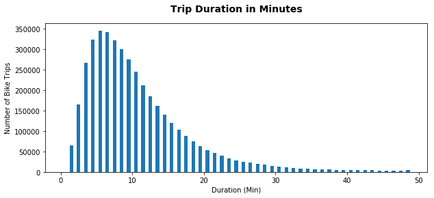

```python
# Duration of the bike rides in MINUTES
binsize = 1
bins = np.arange(0, 50, binsize)
plt.figure(figsize=[10, 4])
plt.hist(data = df_master_clean, x = 'duration_min', bins = bins,rwidth=0.5)
plt.title("Trip Duration in Minutes", y=1.05, fontsize=14, fontweight='bold')
plt.xlabel('Duration (Min)')
plt.ylabel('Number of Bike Trips');
plt.show()
```

### Observation 1)

> From the above histogram we can see that duration (in mins) for majority of the rides fall between the range of 1 to 10 minutes. This shows that users prefer bike rides for smaller durations.

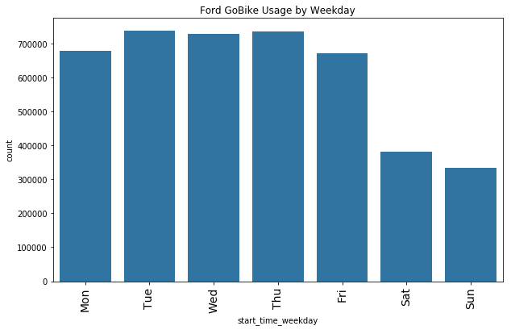

```python
#Weekday usage of the Ford Go bike system
weekday = ['Mon', 'Tue', 'Wed', 'Thu', 'Fri', 'Sat', 'Sun']
plt.figure(figsize=[10, 6])
plt.title('Ford GoBike Usage by Weekday')
base_color=sb.color_palette()[0]
sb.countplot(data = rides,x='start_time_weekday',color=base_color,order=weekday)
plt.xticks(fontsize=14, rotation=90);
```

### Observation 2)

> From the above bar chart we can see that weekdays are the days when most of the bike rides are taken. This shows people are taking bike rides to commute to their workplace,institues etc.

```
''
```

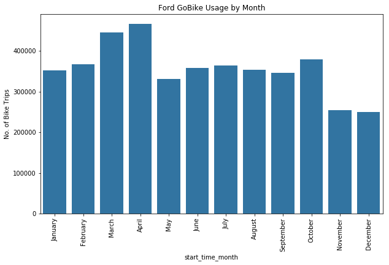

```python
## Month usage of the Ford Go bike system
plt.figure(figsize=[10, 6])
plt.title('Ford GoBike Usage by Month')
base_color=sb.color_palette()[0]
sb.countplot(data = rides,x='start_time_month',color=base_color)
plt.xticks(fontsize=10, rotation=90)
plt.ylabel('No. of Bike Trips');
;
```

#### Observation 4)

> From the above bar chart we can see that March and April are the two months where most people take the bike rides. This is an interesting insigth for our future xplanatory anlysis as to why certain months have higher bike rides.

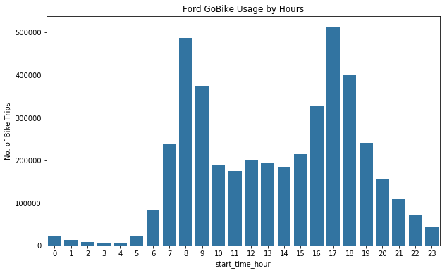

```python
## Hourly usage of the Ford Go bike system
plt.figure(figsize=[10, 6])
plt.title('Ford GoBike Usage by Hours')
base_color=sb.color_palette()[0]
sb.countplot(data = rides,x='start_time_hour',color=base_color)
plt.ylabel('No. of Bike Trips');
```

### Observation 5)

> From the above histogram we can see that there is a spike in bike rides taken during 8-9 am in the morning and 5-6 pm in the morning which further solidifies that the bikes are used to commute.

```
(-1.1227225359189024,
 1.1200304192106343,
 -1.1172289345368118,
 1.1255240205927248)
```

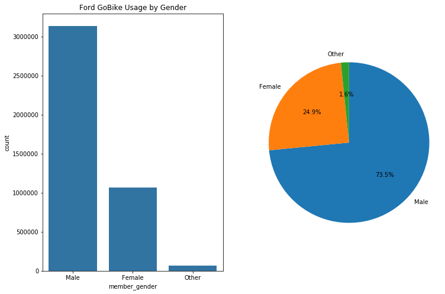

```python
#Gender usage of the Ford Go bike system
plt.figure(figsize = [12, 8]) #figure size for subplots

##Bar chart for Gender usage of the Ford Go bike system
plt.subplot(1, 2, 1) # 1 row, 2 cols, subplot 1
plt.title('Ford GoBike Usage by Gender')
base_color=sb.color_palette()[0]
sb.countplot(data = rides,x='member_gender',color=base_color);

#Pie chart for Gender usage of the Ford Go bike system
plt.subplot(1, 2, 2) # 1 row, 2 cols, subplot 2
sorted_counts = rides['member_gender'].value_counts()
plt.pie(sorted_counts, labels = sorted_counts.index, startangle = 90,autopct='%1.1f%%',counterclock=False);
plt.axis('square')
```

### Observation 6)

> From the above bar chart and pie chart we can observe a very astonishing insight that majority of the rides are taken by Males (73.5 %) as compared to females(24.9%).

```
(-1.1065631218929572,
 1.105959519626133,
 -1.1015400332295315,
 1.1109826082895586)
```

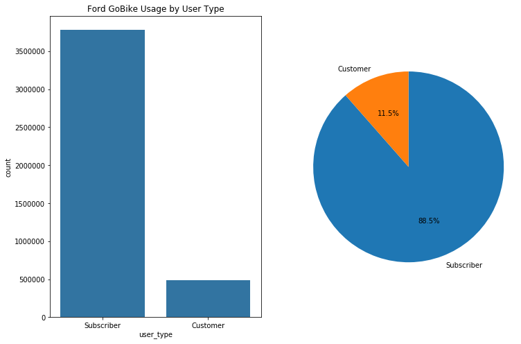

```python
## User Type usage of the Ford Go bike system
plt.figure(figsize = [12, 8]) #figure size for subplots

## Bar chart for User Type usage of the Ford Go bike system
plt.subplot(1, 2, 1) # 1 row, 2 cols, subplot 1
plt.title('Ford GoBike Usage by User Type')
base_color=sb.color_palette()[0]
sb.countplot(data = rides,x='user_type',color=base_color);

#Pie chart for User Type usage of the Ford Go bike system
plt.subplot(1, 2, 2) # 1 row, 2 cols, subplot 2
sorted_counts = rides['user_type'].value_counts()
plt.pie(sorted_counts, labels = sorted_counts.index, startangle = 90,autopct='%1.1f%%',counterclock=False);
plt.axis('square')
```

### Observation 7)

> From the above bar chart and pie chart we can observe 88.5 % users who take the bike ride are subscribers of Ford Go Bike. This is quite understandable as those subscribe to the service usually have to pay less.

```python
rides.member_age.describe()
```

```
count    4.269684e+06
mean     3.523531e+01
std      9.635069e+00
min      1.800000e+01
25%      2.800000e+01
50%      3.300000e+01
75%      4.000000e+01
max      6.500000e+01
Name: member_age, dtype: float64
```

[figure not shown]

```python
# Age group data
plt.figure(figsize=[10, 6])
binsize = 5
bins = np.arange(0, rides['member_age'].max()+binsize, binsize)

plt.hist(data = rides, x = 'member_age', bins = bin_edges);

plt.title("Ford GoBike System User by Age",fontweight='bold')
plt.xlabel('Age of Members (in Years)')
plt.ylabel('No. of Bike Trips');
```

### Observation 8)

> From the above histogram we can observe that majority of the users have age group between 25-40 years with the mean age being 35 years. This shows that people are using the bikes to commute to their workplace.

### Of the features you investigated, were there any unusual distributions? Did you perform any operations on the data to tidy, adjust, or change the form of the data? If so, why did you do this?

> We had to perform a transformation for creating plot distribution of duration_mins where majority of the rides duration is less than 50 mins so we have treated other values as outliers and plot the histogram for only rides with duration less than 50 mins by taking the bins till 50.

## Bivariate Exploration

> In this section, I will investigate further by analysisng the above trends gender and user type wise.

### In the following plots we will see the trends of bike usage gender wise.

```
''
```

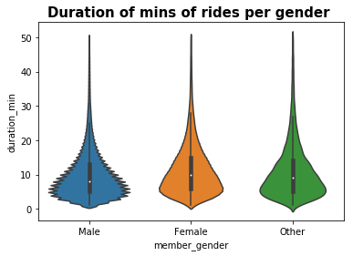

```python
# Box Plot to observe duration of mins of rides gender wise
data_1 = rides.query('duration_min < 51')
sb.violinplot(data = data_1, x = 'member_gender', y = 'duration_min')
plt.title('Duration of mins of rides per gender ',fontsize=15,fontweight='bold');
;
```

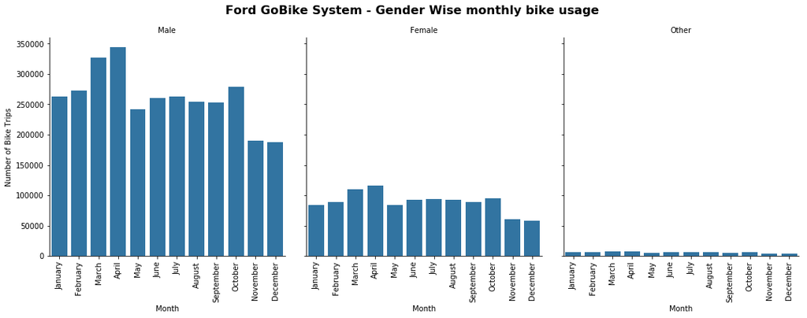

```python
#Bar charts to compare gender wise monthly bike usage
base_color=sb.color_palette()[0]

graph = sb.catplot(data=rides, x='start_time_month', col="member_gender", kind='count', sharey = True,color=base_color);

graph.set_axis_labels("Month", "Number of Bike Trips");
graph.set_titles("{col_name}");

graph.fig.suptitle('Ford GoBike System - Gender Wise monthly bike usage', y=1.05, fontsize=16, fontweight='bold');
graph.set_xticklabels(rotation=90);
```

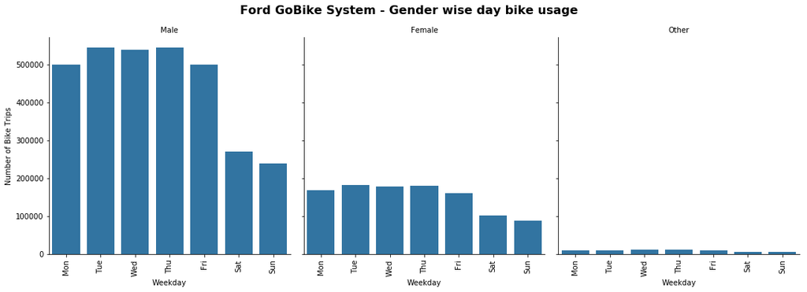

```python
#Bar charts to compare gender wise weekday bike usage

base_color=sb.color_palette()[0]
weekday = ['Mon', 'Tue', 'Wed', 'Thu', 'Fri', 'Sat', 'Sun']

graph = sb.catplot(data=rides, x='start_time_weekday', col="member_gender", kind='count', sharey = True,color=base_color,order=weekday);

graph.set_axis_labels("Weekday", "Number of Bike Trips");
graph.set_titles("{col_name}");

graph.fig.suptitle('Ford GoBike System - Gender wise day bike usage', y=1.05, fontsize=16, fontweight='bold');
graph.set_xticklabels(rotation=90);
```

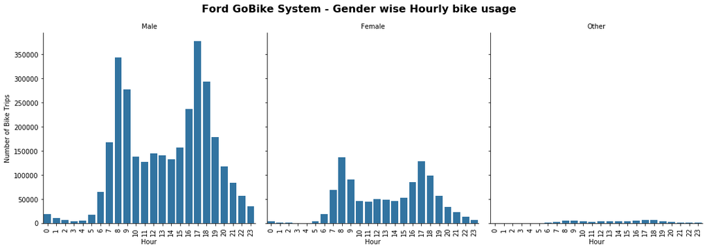

```python
#Bar charts to compare gender wise hourly bike usage

base_color=sb.color_palette()[0]

graph = sb.catplot(data=rides, x='start_time_hour', col="member_gender", kind='count', sharey = True,color=base_color);

graph.set_axis_labels("Hour", "Number of Bike Trips");
graph.set_titles("{col_name}");

graph.fig.suptitle('Ford GoBike System - Gender wise Hourly bike usage', y=1.05, fontsize=16, fontweight='bold');
graph.set_xticklabels(rotation=90);
```

### Observation

> From the above plots we can observe that all the genders follow the same trend for the usage of bikes. For example for every gender the majority of the rides have a duration in the group 0-10 mins. Similalry for month,weekday,hour wise usage also the trend is similar among all the genders.

### In the next series of plots we will see the trends of bike usage per user type.

```
''
```

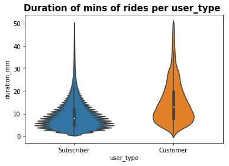

```python
# Violin Plot to observe duration of mins of rides per user type

data_1 = rides.query('duration_min < 51')
sb.violinplot(data = data_1, x = 'user_type', y = 'duration_min')
plt.title('Duration of mins of rides per user_type ',fontsize=15,fontweight='bold');
;
```

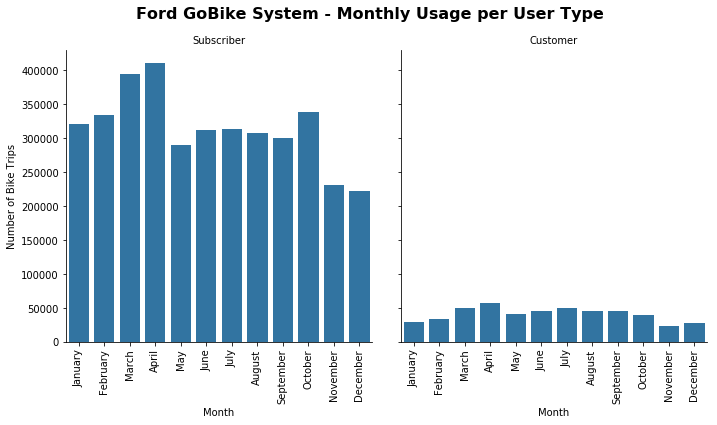

```python
#Bar charts to compare monthly bike usage per user_type

base_color=sb.color_palette()[0]

graph = sb.catplot(data=rides, x='start_time_month', col="user_type", kind='count', sharey = True,color=base_color);

graph.set_axis_labels("Month", "Number of Bike Trips");
graph.set_titles("{col_name}");

graph.fig.suptitle('Ford GoBike System - Monthly Usage per User Type', y=1.05, fontsize=16, fontweight='bold');
graph.set_xticklabels(rotation=90);
```

[figure not shown]

```python
#Bar charts to compare weekday bike usage per user_type

base_color=sb.color_palette()[0]
weekday = ['Mon', 'Tue', 'Wed', 'Thu', 'Fri', 'Sat', 'Sun']

graph = sb.catplot(data=rides, x='start_time_weekday', col="user_type", kind='count', sharey = True,color=base_color,order=weekday);

graph.set_axis_labels("Weekday", "Number of Bike Trips");
graph.set_titles("{col_name}");

graph.fig.suptitle('Ford GoBike System - Weekday Usage per User Type', y=1.05, fontsize=16, fontweight='bold');
graph.set_xticklabels(rotation=90);
```

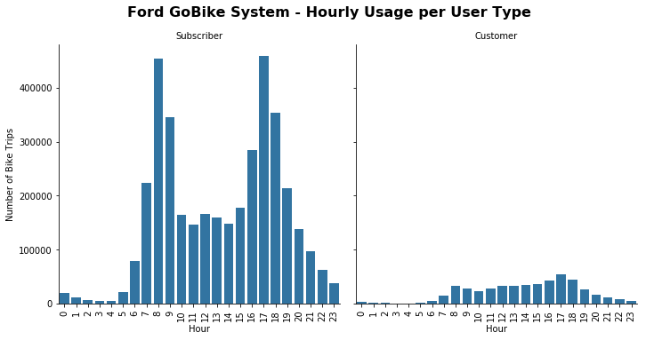

```python
#Bar charts to compare hourly bike usage per user_type

base_color=sb.color_palette()[0]

graph = sb.catplot(data=rides, x='start_time_hour', col="user_type", kind='count', sharey = True,color=base_color);

graph.set_axis_labels("Hour", "Number of Bike Trips");
graph.set_titles("{col_name}");

graph.fig.suptitle('Ford GoBike System - Hourly Usage per User Type', y=1.05, fontsize=16, fontweight='bold');
graph.set_xticklabels(rotation=90);
```

### Observation

> From the above plots we can observe that :

2) Both the user types have same trends for month wise usage of bikes with March and April being the months were most of the rides are taken.

4) The hourly trend shows that for subscribers majority of the rides are taken during hours 8-9 am and 5-6 pm whereas for the customers the majority of the rides are taken from 11 am to 7 pm.

### Talk about some of the relationships you observed in this part of the investigation. How did the feature(s) of interest vary with other features in the dataset?

> After plotting the above plots we obsereved that all the genders follow the same trends. They have similar ride durations and onthly,weekday,hourly usage.

> For different user type we observed that customer takes more rides on weekends and subscribers take more rides from Monday to Friday. Similarly the hourly usage trends also differ for subacribers and customers.

### Did you observe any interesting relationships between the other features (not the main feature(s) of interest)?

> No

## Multivariate Exploration

### Now in this section we will look at the usage trends for every user_type divided gender wise

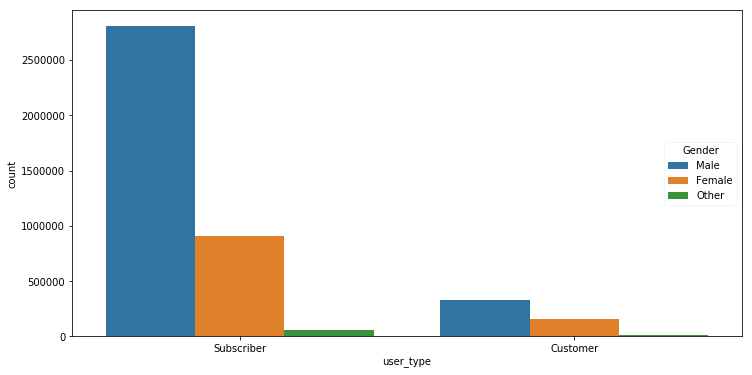

```python
# countplot to observe the usertype and gender wise distribution

plt.figure(figsize=[12, 6])

ax = sb.countplot(data = rides, x = 'user_type', hue = 'member_gender')

ax.legend(loc = 7, framealpha = 0.2,title='Gender')
#ax.legend.set_title('Gender')
plt.xticks(rotation = 0);
```

### Observation 1)

> Both the user types have males in majority as the user. This shows that males are using the Bike Ride service more than females by quite a big margin.

```
''
```

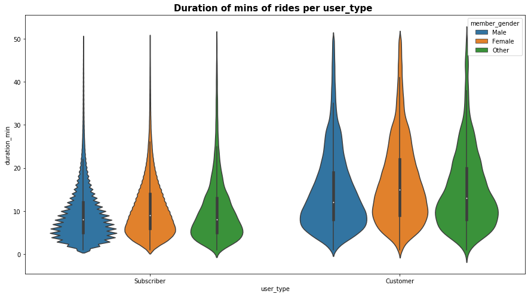

```python
# Violin Plot to observe duration of mins of rides per user type and gender
# removing outliers by taking only rides less than 51 minutes of duration
data_1 = rides.query('duration_min < 51')
plt.figure(figsize=[15, 8])
plt_1=sb.violinplot(data = data_1, x = 'user_type', y = 'duration_min',hue='member_gender')
ax.legend(loc = 7, framealpha = 0.2,title='Gender')
plt.title('Duration of mins of rides per user_type ',fontsize=15,fontweight='bold');
;
```

### Observation 2

> The user type customer have more rides of longer durations. This shows that they are using this service for fun,travelling and excercise.

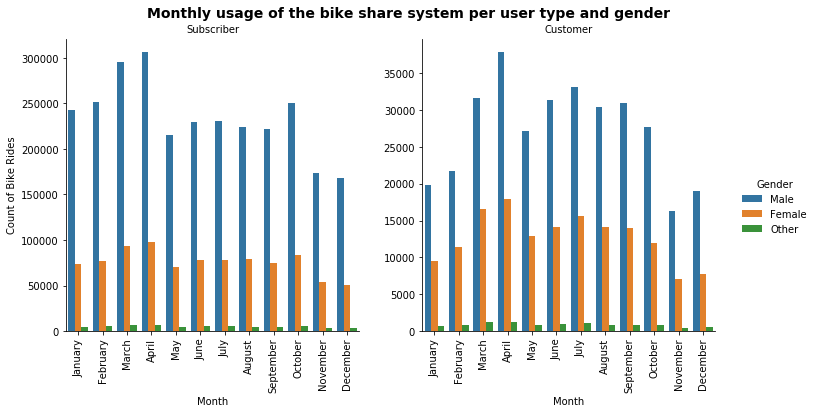

```python
# bar charts to plot monthly usege of the bike sharing system per user type and gender
plt.figure(figsize=[15, 8])

g = sb.catplot(data=rides, x='start_time_month', col="user_type", hue="member_gender", kind='count', sharey = False)
g.set_axis_labels("Month", "Count of Bike Rides")
g._legend.set_title('Gender')
g.set_titles("{col_name}")
g.fig.suptitle('Monthly usage of the bike share system per user type and gender', y=1.02, fontsize=14, fontweight='bold')
g.set_xticklabels(rotation=90);
```

### Observation 3

> User type Subscriber uses the service more in the intial months of the year whereas the user type customer use the service more in the months April to September.

[figure not shown]

```python
# bar charts to plot the weekday usege of the bike sharing system per user type and gender
plt.figure(figsize=[12, 6])

weekday = ['Mon', 'Tue', 'Wed', 'Thu', 'Fri', 'Sat', 'Sun']
g = sb.catplot(data=rides, x='start_time_weekday', col="user_type", hue='member_gender', kind='count', sharey = False,
                order = weekday)
g.set_axis_labels("Weekday", "Count of Bike Rides")
g._legend.set_title('Gender')
g.set_titles("{col_name}")
g.fig.suptitle('Weekly usage of the bike share system per user type and gender', y=1.02, fontsize=15, fontweight='bold');
```

### Observation 4

> User type Subscriber uses the service more during the working days (Monday-Friday) whereas user type Customer use the service most during the weekends (Friday-Sunday).

[figure not shown]

```python
# bar chart to plot hourly usege of the bike sharing system per user type and gender
plt.figure(figsize=[20, 10])

g = sb.catplot(data=rides, x='start_time_hour', col="user_type", hue='member_gender', kind='count', sharey = False)
g.set_axis_labels("Hour", "Count of Bike Rides")
g._legend.set_title('Gender')
g.set_titles("{col_name}")
g.fig.suptitle('Hourly usage of the bike share system per user type and gender', y=1.02, fontsize=15, fontweight='bold');
```

### Observation 5

> User type Subscriber uses the service more during the the hours 8-9am and 5-6 pm showing that they are using the service to commute to workplace and back home. The user type customer on the other hand use the service most during hours 11 am to 7 pm.

### Talk about some of the relationships you observed in this part of the investigation. Were there features that strengthened each other in terms of looking at your feature(s) of interest?

> We have find some interesting trends for user type subscribers. They use the service most during the working days and during the hours when the colleges and workplace satrts(8-9am) and when they finish (5-6 pm) which shows that subscribers have subscribed to the service so that can commute to their workplace or institutes. Where as the trends for user type customer shows they use the service for enjoying purposes with weekend being the days when the demand is the most.

### Were there any interesting or surprising interactions between features?

> From our plots abve we observe that the trends are very identical among different gender types. Which shows both are using the service for same purposes.

### Sources Reffered

https://stackoverflow.com/ https://www.udacity.com/ https://stackabuse.com/ https://github.com/